# Wiskunde voor Statistiek

H1 - Verzamelingen

Witek ten Hove

Deze notebook hoort bij het boek [“Wiskunde voor Statistiek”](https://shop.coutinho.nl/store_nl/wiskunde-voor-statistiek.html) en demonstreert de concepten die hierin worden besproken met behulp van R.

Een **verzameling** is een duidelijk afgebakend geheel van objecten, die aan bepaalde voorwaarden moeten voldoen, willen ze tot die verzameling behoren. De objecten worden de *elementen* van de verzameling genoemd.

```r
n <- 5
A <- letters[1:n]
cat("De variabele A bevat de verzameling van de eerste", length(A), "letters van het alfabet: ", A)
```

```
De variabele A bevat de verzameling van de eerste 5 letters van het alfabet:  a b c d e
```

In bovenstaande code hebben we een variabele A benoemd en hieraan de eerste 5 letters van het alfabet als elementen toegevoegd. Een één-dimensionele verzameling van enkelvoudige elementen wordt in R een `vector` genoemd.

**Vraag:** Wat doet de functie `length()`?

Stel we hebben twee verzamelingen B en C en we beschrijven C als de verzameling van elementen uit B die aan een bepaald criterium voldoen.

```r
B <- 1:20
t1 <- B < 10
C <- B[t1]
cat("B bevat de cijfers", min(B), "t/m", max(B), ". De variabele t1 bevat de uitkomsten van de test 'Is het element uit B kleiner dan 10?'(", head(t1, 3),"...) en C bevat alle elementen uit B waarvoor geldt dat de uitkomst van de test TRUE is:", C)
```

```
B bevat de cijfers 1 t/m 20 . De variabele t1 bevat de uitkomsten van de test 'Is het element uit B kleiner dan 10?'( TRUE TRUE TRUE ...) en C bevat alle elementen uit B waarvoor geldt dat de uitkomst van de test TRUE is: 1 2 3 4 5 6 7 8 9
```

**Vraag:** Wat doen de functies `min()`, `max()` en `head()`?

**Vraag:** Zoek uit met welke functie je de laatste zes elementen van een vector kunt selecteren.

We kunnen nu testen welke elementen van B niet in C voorkomen.

```r
t2 <- B %in% C
D <- B[!t2]
cat("De verzameling D bevat alle elementen uit B die niet tot C behoren:", D)
```

```
De verzameling D bevat alle elementen uit B die niet tot C behoren: 10 11 12 13 14 15 16 17 18 19 20
```

**Vraag:** Wat doet het uitroepteken in bovenstaande code?

```r
m <- 100
F <- seq(1, m, 2)
E <- c(3, 5, 7)
t3 <- E %in% F
cat("De vector t3 bevat de uitkomsten van de test 'E komt voor in F':", t3)
```

```
De vector t3 bevat de uitkomsten van de test 'E komt voor in F': TRUE TRUE TRUE
```

E is dus een deelverzameling van F:

$\text{ }E \subset F$

en dus omvat F alle elementen uit de verzameling E:

$\text{ }F \supset E$

**Vraag:** Test of geldt dat $F \subset E$

**Vraag:** Toon aan dat als geldt dat $E \subset F$ en $E \supset F$, de verzamelingen E en F gelijk zijn ($F = E$).

Stel we definieren twee verzamelingen G = {1, 2, 3, 4, 5} en H = {4, 5, 6, 7, 8} en I als de verzameling van elementen die zowel in G als H voorkomen.

```r
G <- 1:5
H <- 4:8
t4 <- G %in% H
I <- G[t4]
cat("De vector t4 bevat de uitkomsten van de test 'G komt voor in H':", t4, "en I bevat dus", length(I), "elementen.")
```

```
De vector t4 bevat de uitkomsten van de test 'G komt voor in H': FALSE FALSE FALSE TRUE TRUE en I bevat dus 2 elementen.
```

De **doorsnede**, $\cap$, is de verzameling van elementen die zowel tot G als tot H behoren:

$\text{ }G \cap H =$ {4, 5}

Stel we definieren twee verzamelingen J = {3, 5, 7} en K = {1, 2, 4} en L als de verzameling van elementen die zowel in J als K voorkomen.

```r
J <- E
K <- c(1, 2, 4)
t5 <- J %in% K
L <- K[t5]
cat("De vector t5 bevat de uitkomsten van de test 'J komt voor in K':", t5, "en L bevat dus", length(L), "elementen.")
```

```
De vector t5 bevat de uitkomsten van de test 'J komt voor in K': FALSE FALSE FALSE en L bevat dus 0 elementen.
```

De **lege verzameling**, $\varnothing$, is een verzameling die geen enkel element bevat. In het bovenstaande voorbeeld zijn J en K **disjuncte** (elkaar uitsluitende) verzamelingen:

$\text{ }J \cap K = \varnothing$

De **vereniging** van twee verzamelingen J en K, $\cup$, is de verzameling waarvan de elementen tot J of tot K of tot beide behoren.

$\text{ }J \cup K =$ {1, 2, 3, 4, 5, 7}

**Vraag:** Zoek op wat de functie `unique()` doet.

#### $\mathbb{N}$ine $\mathbb{Z}$ulu $\mathbb{Q}$ueens $\mathbb{R}$uled $\mathbb{C}$hina

In R (of iedere andere programmeertaal) kunnen we geen oneindige verzamelingen aanmaken, zoals bijvoorbeeld de verzameling $\mathbb{N}$ van positieve gehele getallen en het getal 0 (natuurlijke getallen):

$\text{ }\mathbb{N} =$ {0, 1, 2, 3, 4, 5, 6, 7, 8, 9 …….}

**Vraag:** Waarom niet?

Alle positieve en negatieve gehele getallen en het getal 0 zijn elementen van de verzameling $\mathbb{Z}$ (gehele getallen):

$\text{ }\mathbb{Z} =$ {…….-4, -3, -2, -1, 0, 1, 2, 3, 4 …….}

Alle combinaties $\frac ab$ met a, b $\in \mathbb{Z}$ en b $\neq$ 0 behoren tot de verzameling van quotiënten, $\mathbb{Q}$ (**ratio**nale getallen).

**Vraag:** Toon aan dat geldt $\mathbb{Z} \subset \mathbb{Q}$.

Irrationale getallen zijn getallen die niet uit kunnen worden uitgedrukt in een quotiënt van twee gehele getallen. Voorbeelden hiervan zijn $\sqrt{2}$ en $\pi$.

De verzameling $\mathbb{R}$ (reële getallen) bevat alle rationale en irrationale getallen. $\mathbb{C}$ is de verzameling van alle complexe getallen (het is op dit moment voldoende om te weten dat het hier gaat om combinaties van alle reële getallen met het imaginaire getal $\sqrt{-1}$). Er geldt dus:

$\text{ }\mathbb{N} \subset \mathbb{Z} \subset \mathbb{Q} \subset \mathbb{R} \subset \mathbb{C}$

#### Toepassing verzamelingenleer op kansberekening

```r
D1 <- 1:6
D2 <- 1:6
outer(D1, D2, paste, sep = ",")
```

```
     [,1]  [,2]  [,3]  [,4]  [,5]  [,6]
[1,] "1,1" "1,2" "1,3" "1,4" "1,5" "1,6"
[2,] "2,1" "2,2" "2,3" "2,4" "2,5" "2,6"
[3,] "3,1" "3,2" "3,3" "3,4" "3,5" "3,6"
[4,] "4,1" "4,2" "4,3" "4,4" "4,5" "4,6"
[5,] "5,1" "5,2" "5,3" "5,4" "5,5" "5,6"
[6,] "6,1" "6,2" "6,3" "6,4" "6,5" "6,6"
```

**Vraag:** Hoe groot is de verzameling van combinaties van twee verzamelingen D1 en D2 die beide bestaan uit de elementen {1, 2, 3, 4, 5, 6}?

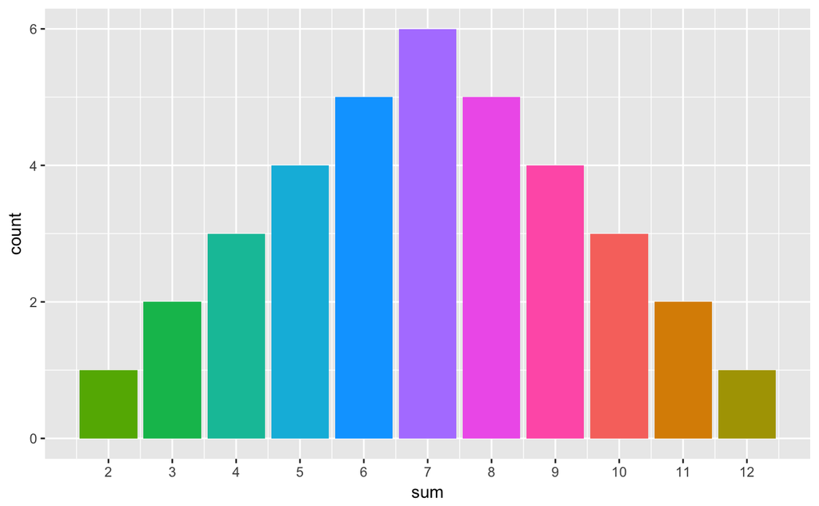

```r
library(ggplot2)
dice <- expand.grid(dice1 = D1, dice2 = D2)
dice$sum <- dice$dice1 + dice$dice2
ggplot(dice, aes(sum)) + geom_bar(aes(fill = as.character(sum))) + scale_x_continuous(breaks = unique(dice$sum)) + theme(legend.position="none")
```

**Vraag:** Wat is de kans dat iemand met twee dobbelstenen zes gooit?